# Phenolgy and Biomass

Source files available on [github](https://github.com/camposfa/Transects)

# Major steps

1. Load phenology data and clean it up: jump
2. Smooth phenology data to obtain monthly pheno indices: jump
3. Load transect data and clean it up: jump
4. Specify minimum DBH thresholds for phenology species in transects: jump
5. Estimate maximum potential biomass for each species: jump
6. Combine phenology with transect data to obtain actual monthly biomass estimates: jump

Prepare R environment

```r
setwd("C:/Users/Fernando/Dropbox/R/Transects")
Sys.setenv(TZ='UTC')
x <- list("ggplot2",
          "RColorBrewer",
          "plyr",
          "scales",
          "reshape2",
          "RODBC",
          "mgcv",
          "xtable",
          "lubridate")
lapply(x, require, character.only = T)
```

## Step 1: Load phenology data and clean it up

### Obtain Data

#### Option 1

- If you have access, pull current data from PACE database
- Must create SSH tunnel first using plink
- Change dsn=“PACE” to whatever your PACE ODBC connection is called
- *Remove comments if using!*

```r
# Must create SSH tunnel first (plink)
# ch <- odbcConnect(dsn = "PACE")
# pheno.q <- "SELECT
# tblTaxon.SpeciesName,
# tblTaxon.CodeName,
# tblPhenologyTree.ID
# AS TreeID,
# tblPhenologyMonthly.Year,
# tblPhenologyMonthly.Month,
# tblPhenologyMonthly.DateOf,
# tblPhenologyMonthly.FruitCoverID,
# tblPhenologyMonthly.FruitMaturityID
# FROM
# (tblTaxon INNER JOIN tblPhenologyTree
# ON tblTaxon.ID = tblPhenologyTree.TaxonID)
# INNER JOIN
# tblPhenologyMonthly
# ON tblPhenologyTree.ID =
# tblPhenologyMonthly.PhenologyTreeID
# ORDER BY
# tblTaxon.SpeciesName,
# tblPhenologyMonthly.Year,
# tblPhenologyMonthly.Month"
# pheno <- sqlQuery(ch, pheno.q)
# odbcCloseAll()
# write.csv(pheno, file = "pace_pheno.csv", row.names = FALSE)
```

#### Option 2

- Contact me if you are interested in the raw data

```r
pheno <- read.csv("pace_pheno.csv")
```

### Clean up data

```r
# Rename variables for consistent style
names(pheno) <- c("species_name",
                  "code_name",
                  "tree_id",
                  "year_of",
                  "month_of",
                  "date_of",
                  "fruit_coverage",
                  "fruit_maturity")
pheno$tree_id <- factor(pheno$tree_id)
pheno$month_of <- factor(pheno$month_of,
                         labels = month.abb[1:12])
pheno$date_of <- as.Date(pheno$date_of)

# Fix maturity code 5 (change to zero)
pheno[which(pheno$fruit_maturity == 5), ]$fruit_maturity <- 0

# Exclude 2006 pheno data because no maturity info
pheno <- subset(pheno, year_of > 2006)

# Calculate number of trees of each species
count_tree_species <- ddply(ddply(pheno,
                                   .(species_name, tree_id),
                                   summarize,
                                   length(tree_id)),
                             .(species_name),
                             summarize,
                             num_trees = length(tree_id))
```

### Unique trees for each pheno species

|  | species_name | num_trees |
| --- | --- | --- |
| 1 | Alibertia edulis | 8 |
| 2 | Allophylus occidentalis | 12 |
| 3 | Annona reticulata | 11 |
| 4 | Apeiba tibourbou | 3 |
| 5 | Bauhinia ungulata | 10 |
| 6 | Bromelia pinguin | 10 |
| 7 | Bromelia plumieri | 10 |
| 8 | Bursera simaruba | 14 |
| 9 | Byrsonima crassifolia | 12 |
| 10 | Calycophyllum candidissimum | 10 |
| 11 | Cassia grandis | 5 |
| 12 | Cecropia peltata | 14 |
| 13 | Cordia guanacastensis | 10 |
| 14 | Cordia panamensis | 11 |
| 15 | Curatella americana | 7 |
| 16 | Diospyros salicifolia | 7 |
| 17 | Diphysa americana | 10 |
| 18 | Dipterodendron costaricense | 5 |
| 19 | Eugenia salamensis | 2 |
| 20 | Ficus cotinifolia | 11 |
| 21 | Ficus goldmani | 6 |
| 22 | Ficus hondurensis | 6 |
| 23 | Ficus morazaniana | 6 |
| 24 | Ficus obtusifolia | 2 |
| 25 | Ficus ovalis | 6 |
| 26 | Ficus sp. | 3 |
| 27 | Genipa americana | 11 |
| 28 | Guazuma ulmifolia | 10 |
| 29 | Guettarda macrosperma | 11 |
| 30 | Hymenaea courbaril | 9 |
| 31 | Jacquinia nervosa | 12 |
| 32 | Karwinskia calderoni | 11 |
| 33 | Licania arborea | 10 |
| 34 | Luehea candida | 15 |
| 35 | Luehea speciosa | 10 |
| 36 | Maclura tinctoria | 12 |
| 37 | Malvaviscus arboreus | 9 |
| 38 | Manilkara chicle | 11 |
| 39 | Mastichodendron capiri | 1 |
| 40 | Muntingia calabura | 3 |
| 41 | Psidium guajava | 4 |
| 42 | Randia monantha | 14 |
| 43 | Randia thurberi | 9 |
| 44 | Sapium grandulosum | 5 |
| 45 | Sciadodendron excelsum | 10 |
| 46 | Sebastiana pavoniana | 7 |
| 47 | Simarouba glauca | 9 |
| 48 | Sloanea terniflora | 4 |
| 49 | Spondias mombin | 12 |
| 50 | Spondias purpurea | 2 |
| 51 | Stemmadenia obovata | 13 |
| 52 | Tabebuia ochracea | 4 |
| 53 | Trichilia americana | 5 |
| 54 | Trichilia martiana | 7 |
| 55 | Vachellia collinsii | 25 |
| 56 | Zuelania guidonia | 10 |

### Calculate pheno indices for each phenology record

- index_avail = (Maturity / 4) x (Coverage / 4)
- index_avail is maximum (1) if full coverage and maturity
- index_avail is zero if either coverage or maturity is zero

```r
pheno$index_avail <- (pheno$fruit_coverage / 4) * (pheno$fruit_maturity / 4)
```

### Filter pheno data (remove some species)

```r
# MCAP: only one tree after 2006
# Ficus sp.: not useful if species unknown
# BOCE: no pheno trees after 2006
# HCOU: fruit not eaten

pheno <- subset(pheno,
                species_name != "Bunchosia ocellata" &
                  species_name != "Ficus sp." &
                  species_name != "Mastichodendron capiri" &
                  species_name != "Hymenaea courbaril"
)

# Fix some name errors
pheno$species_name <- as.character(pheno$species_name)
pheno[pheno$code_name == "SGLN",]$species_name <- "Sapium glandulosum"
pheno$species_name <- factor(pheno$species_name)
pheno$code_name <- factor(pheno$code_name)

# Generate list of unique species, for later use
species <- unique(pheno[, 1:2])
row.names(species) <- NULL
```

### Monthly plot of index_availability indices for selected species

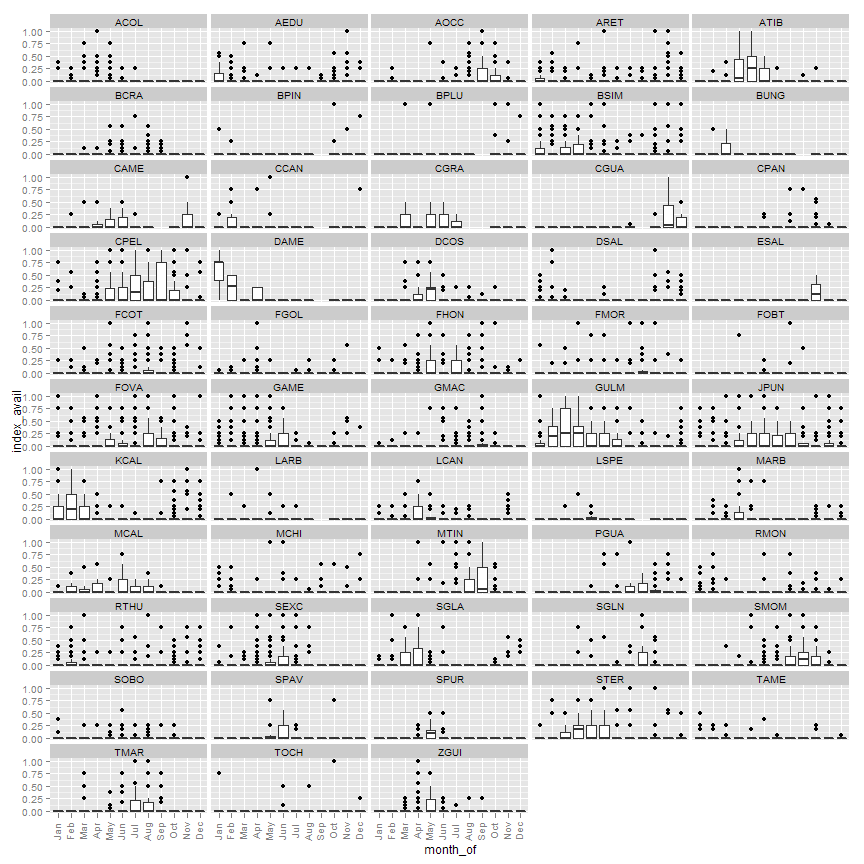

```r
ggplot(pheno, aes(x = month_of, y = index_avail)) +
  geom_boxplot() +
  theme(axis.text.x = element_text(angle = 90, vjust = 0.25)) +
  facet_wrap(~code_name, ncol = 5)
```

## Step 2: Smooth phenology data to obtain monthly pheno indices

### GAM smoothing of phenology data using availability index

- Applied to each species separately
- Smoothed with cyclic cubic regression spline, which forces the ends (January / January) to match
- Using tree_id as random effect

```r
pheno_gams <- list()

for(i in 1:length(levels(pheno$species_name)))
{
  pheno_s <- subset(pheno, species_name == levels(species_name)[i])

  mod_s <- gamm(index_avail ~
                  s(as.numeric(month_of),
                    bs = "cc"),
                data = pheno_s,
                random = list(tree_id = ~1),
                knots = list(month_of = c(1, 13)))

  pheno_gams[[i]] <- mod_s$gam
}

# Create data frame of model results for all species
fruit_avail <- matrix(nrow = length(levels(pheno$species_name)),
                      ncol = 12)
for(i in 1:length(levels(pheno$species_name)))
{
  for(j in 1:12)
  {
    pred <- predict(pheno_gams[[i]],
                    newdata = subset(pheno,
                                     species_name ==
                                       levels(species_name)[i]))
    pred[pred < 0] <- 0
    temp <- data.frame(cbind(subset(pheno,
                                    species_name ==
                                      levels(species_name)[i])$month_of,
                             pred))
    fruit_avail[i,j] <- mean(subset(temp, V1 == j)$pred)
  }
}

fruit_avail <- data.frame(fruit_avail)
names(fruit_avail) <- rep(month.abb, 1)
fruit_avail$species_name <- levels(pheno$species_name)

# Merge to obtain species code names
fruit_avail <- merge(fruit_avail,
                     species,
                     by.x = "species_name",
                     by.y = "species_name",
                     sort = F)

# Convert from wide to long format
fruit_avail <- melt(fruit_avail,
                    id.vars = c("species_name", "code_name"))
names(fruit_avail)[3] <- "month_of"
```

### Plot all smoothed pheno index_availability estimates

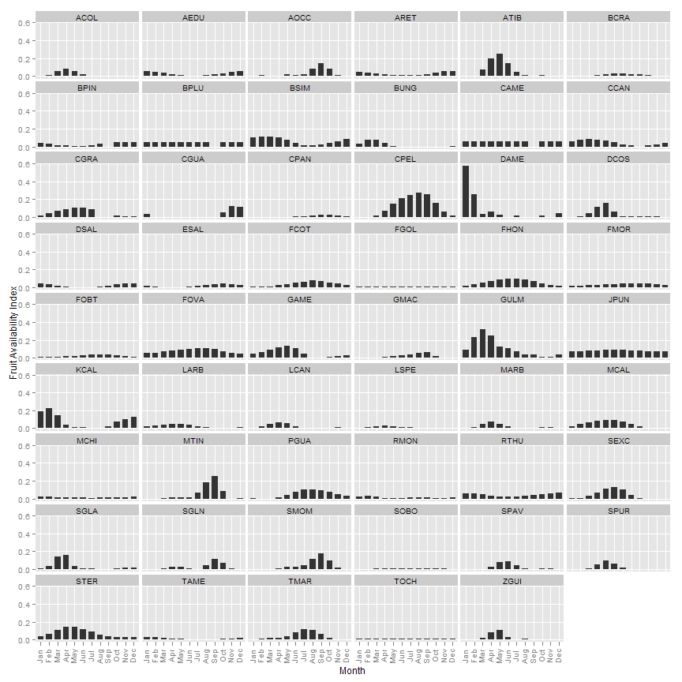

```r
ggplot(fruit_avail, aes(x = month_of, y = value)) +
  geom_bar(stat = "identity", width = 0.7) +
  facet_wrap(~code_name, ncol = 6) +
  theme(axis.text.x = element_text(angle = 90, vjust = 0.25),
        panel.grid.minor = element_blank()) +
  labs(x = "Month", y = "Fruit Availability Index")
```

Pheno data for some species looks very problematic, notably ARET, RMON, SOBO, TAME, and TOCH

## Step 3: Load transect data and clean it up

### Load transect data

- Contact me if you are interested in the raw data

```r
tr <- read.csv("Transects.csv")
```

### Clean up transect data

```r
# Rename variables for consistent style
names(tr) <- c("tree_id", "transect_id",
               "old_transect_id", "transect_start",
               "transect_end", "date_of", "seq_num",
               "x", "y", "species_name",
               "prop_in_transect", "n_stems",
               "area", "cbh", "dbh")

# Fix issue with species name
tr$species_name <- as.character(tr$species_name)
tr[tr$species_name == "Maclura tinctoria x",]$species_name <-
  "Maclura tinctoria"
tr$species_name <- factor(tr$species_name)

# Get transect trees from target pheno species
tr_pheno <- tr[tr$species_name %in% species$species_name,]

# Merge to obtain code names
tr_pheno <- merge(tr_pheno,
                  species,
                  by.x = "species_name",
                  by.y = "species_name",
                  sort = F)

# Sort
tr_pheno <- tr_pheno[with(tr_pheno, order(tree_id)),]

# Clean up column order and row names
tr_pheno <- tr_pheno[, c(2:7, 1, 16, 8:15)]
row.names(tr_pheno) <- NULL

# Fill in fixed DBH for bromeliads, since it is not recorded
# Using 5 cm per fruiting plant
# Also ensure that each has a positive n_stems
tr_pheno[(tr_pheno$code_name=="BPLU" |
            tr_pheno$code_name=="BPIN"),]$dbh <- 5
tr_pheno[((tr_pheno$code_name=="BPLU" |
             tr_pheno$code_name=="BPIN") &
            is.na(tr_pheno$n_stems)),]$n_stems <- 1

# Weight bromeliad DBH by n_stems
tr_pheno[(tr_pheno$code_name=="BPLU" |
            tr_pheno$code_name=="BPIN"),]$dbh <-
  tr_pheno[(tr_pheno$code_name=="BPLU" |
              tr_pheno$code_name=="BPIN"),]$dbh *
  tr_pheno[(tr_pheno$code_name=="BPLU" |
              tr_pheno$code_name=="BPIN"),]$n_stems
```

## Step 4: Specify minimum DBH thresholds for phenology species in transects

### Load FPV data

- Contact me if you are interested in the raw data

```r
fpv <- read.csv("AllFPV.csv")
```

### Clean up the FPV data

```r
# Create dbh column
fpv$dbh <- sqrt((4 * fpv$Area) / pi)

# Fill in fixed DBH for bromeliads, since it is not recorded
# Using 5 cm per fruiting plant
# Also ensure that each bromeliad fpv has a positive NFruiting
fpv[(fpv$Code=="BPLU" | fpv$Code=="BPIN"),]$dbh <- 5
fpv[(fpv$Code=="BPLU" | fpv$Code=="BPIN") &
      is.na(fpv$NFruiting),]$NFruiting <- 1

# Weight bromeliad DBH by NFruiting
fpv[(fpv$Code=="BPLU" | fpv$Code=="BPIN"),]$dbh <-
  fpv[(fpv$Code=="BPLU" | fpv$Code=="BPIN"),]$dbh *
  fpv[(fpv$Code=="BPLU" | fpv$Code=="BPIN"),]$NFruiting

# Remove NA values and extra columns, because not useful here
fpv <- subset(fpv, !is.na(dbh))[, c(8, 3, 26)]

# Rename variables for consistent style
names(fpv) <- c("time_stamp", "code_name", "dbh")

# Restrict to pheno species and sort by species & dbh
fpv <- fpv[fpv$code_name %in% species$code_name, ]
fpv <- fpv[with(fpv, order(code_name, dbh)), ]
```

### Find minimum DBHs from FPV data

```r
# Store uncorrected min dbhs
min_dbh <- ddply(fpv,
                 .(code_name),
                 summarize,
                 threshold_dbh = min(dbh, na.rm=TRUE),
                 n.trees = length(dbh))
```

### Plot DBHs for each species to identify problem cases

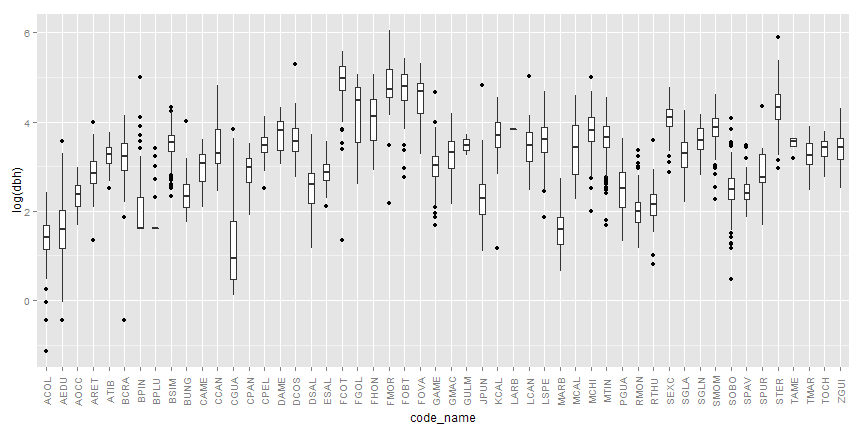

```r
# Look at unchecked min dbhs, log tranformed
ggplot(fpv, aes(x = code_name, y = log(dbh))) +
  geom_boxplot(width=0.5) +
  theme(axis.text.x = element_text(angle=90, vjust=0.5))
```

### Set min dbh for problem species case-by-case

- I tried automating this, but it didn't work well
- If you want to see the detail, you can contact me or check the “fpv_fix_dbh_verbose” chunk of code in the source file

```r
# Fix species with the most egregious lower outliers:
# ACOL, AEDU, ARET, BCRA, FCOT, FMOR, KCAL,
# LSPE, MCHI, MTIN, SOBO
min_dbh[min_dbh$code_name == "ACOL", ]$threshold_dbh <-
  head(subset(fpv, code_name == "ACOL"))$dbh[4]

min_dbh[min_dbh$code_name == "AEDU", ]$threshold_dbh <-
  head(subset(fpv, code_name == "AEDU"))$dbh[2]

min_dbh[min_dbh$code_name == "ARET", ]$threshold_dbh <-
  head(subset(fpv, code_name == "ARET"))$dbh[2]

min_dbh[min_dbh$code_name == "BCRA", ]$threshold_dbh <-
  head(subset(fpv, code_name == "BCRA"))$dbh[2]

min_dbh[min_dbh$code_name == "FCOT", ]$threshold_dbh <-
  head(subset(fpv, code_name == "FCOT"))$dbh[2]

min_dbh[min_dbh$code_name == "FMOR", ]$threshold_dbh <-
  head(subset(fpv, code_name == "FMOR"))$dbh[2]

min_dbh[min_dbh$code_name == "KCAL", ]$threshold_dbh <-
  head(subset(fpv, code_name == "KCAL"))$dbh[2]

min_dbh[min_dbh$code_name == "LSPE", ]$threshold_dbh <-
  head(subset(fpv, code_name == "LSPE"))$dbh[2]

min_dbh[min_dbh$code_name == "MCHI", ]$threshold_dbh <-
  head(subset(fpv, code_name == "MCHI"))$dbh[2]

min_dbh[min_dbh$code_name == "MTIN", ]$threshold_dbh <-
  head(subset(fpv, code_name == "MTIN"))$dbh[3]

min_dbh[min_dbh$code_name == "SOBO", ]$threshold_dbh <-
  head(subset(fpv, code_name == "SOBO"))$dbh[2]
```

### Adjust minimum dbh thresholds for 3 additional species: TAME, SEXC, SGLN

These thresholds have been fudged slightly to include the largest tree(s) of that species in the transects, each of which falls just below the FPV-based cutoff.

```r
min_dbh[min_dbh$code_name == "TAME", ]$threshold_dbh <-
  rev(sort(subset(tr, species_name == "Trichilia americana")$dbh))[1]

min_dbh[min_dbh$code_name == "SEXC", ]$threshold_dbh <-
  rev(sort(subset(tr, species_name == "Sciadodendron excelsum")$dbh))[1]

min_dbh[min_dbh$code_name == "SGLN", ]$threshold_dbh <-
  rev(sort(subset(tr, species_name == "Sapium glandulosum")$dbh))[2]
```

### Subset tr_pheno to include only pheno species

```r
# Restrict transect data to pheno species
tr_pheno <- tr_pheno[tr_pheno$code_name %in% species$code_name, ]

# Remove transect trees without dbh
tr_pheno <- subset(tr_pheno, !is.na(dbh))
```

### Determine if each tree in the transect data meets the minimum DBH criteria

```r
# Set "usable" flag to indicate if tree dbh >= threshold
tr_pheno$usable <- FALSE
for(i in 1:nrow(tr_pheno))
{
  tr_pheno[i, ]$usable <- tr_pheno[i, ]$dbh >=
    (min_dbh[which(as.character(min_dbh$code_name) ==
                     as.character(tr_pheno[i, ]$code_name)),]$threshold_dbh)
}

# Count number of usable transect trees for each species
count_usable <- ddply(tr_pheno,
                      .(code_name),
                      function(df)
                        length(df[df$usable == TRUE, ]$tree_id))
names(count_usable)[2] <- "num_trees"
```

### Number of usable trees in transects

|  | code_name | num_trees |
| --- | --- | --- |
| 1 | ACOL | 696 |
| 2 | AEDU | 147 |
| 3 | AOCC | 61 |
| 4 | ARET | 15 |
| 5 | ATIB | 8 |
| 6 | BCRA | 59 |
| 7 | BPIN | 235 |
| 8 | BPLU | 113 |
| 9 | BSIM | 74 |
| 10 | BUNG | 81 |
| 11 | CAME | 12 |
| 12 | CCAN | 30 |
| 13 | CGUA | 139 |
| 14 | CPAN | 44 |
| 15 | CPEL | 5 |
| 16 | DAME | 1 |
| 17 | DCOS | 7 |
| 18 | DSAL | 72 |
| 19 | ESAL | 34 |
| 20 | FCOT | 2 |
| 21 | FOVA | 0 |
| 22 | GAME | 45 |
| 23 | GMAC | 14 |
| 24 | GULM | 33 |
| 25 | JPUN | 14 |
| 26 | KCAL | 8 |
| 27 | LARB | 0 |
| 28 | LCAN | 56 |
| 29 | LSPE | 46 |
| 30 | MARB | 183 |
| 31 | MCHI | 15 |
| 32 | MTIN | 13 |
| 33 | PGUA | 6 |
| 34 | RMON | 41 |
| 35 | RTHU | 16 |
| 36 | SEXC | 1 |
| 37 | SGLA | 4 |
| 38 | SGLN | 2 |
| 39 | SMOM | 34 |
| 40 | SOBO | 76 |
| 41 | SPAV | 64 |
| 42 | SPUR | 12 |
| 43 | STER | 3 |
| 44 | TAME | 1 |
| 45 | TMAR | 1 |
| 46 | TOCH | 12 |
| 47 | ZGUI | 13 |

## Step 5: Estimate maximum potential biomass for each species

### Biomass estimates

- Assumes every tree is fruiting at max potential
- Calculated by applying Peters 1998 formula on each tree and multiplying by the proportion of the tree in transect, then summed for each species

```r
biomass <- ddply(tr_pheno, .(code_name),
                 function(df)
                   sum(df[df$usable == TRUE,]$prop_in_transect *
                         47 * (df[df$usable == TRUE,]$dbh ^ 1.9),
                       na.rm=TRUE) / 1000)
names(biomass)[2] <- "biomass_total_kg"

# Biomass per hectare
biomass$biomass_max_kg_ha <- (biomass$biomass_total_kg / (151 * 200 / 10000))

# Total basal area
biomass$area_total <- ddply(tr_pheno,
                            .(code_name),
                            function(df) sum(df[df$usable ==
                                                  TRUE, ]$area,
                                             na.rm=TRUE))[, 2]
```

# Plot max potential biomass for each species

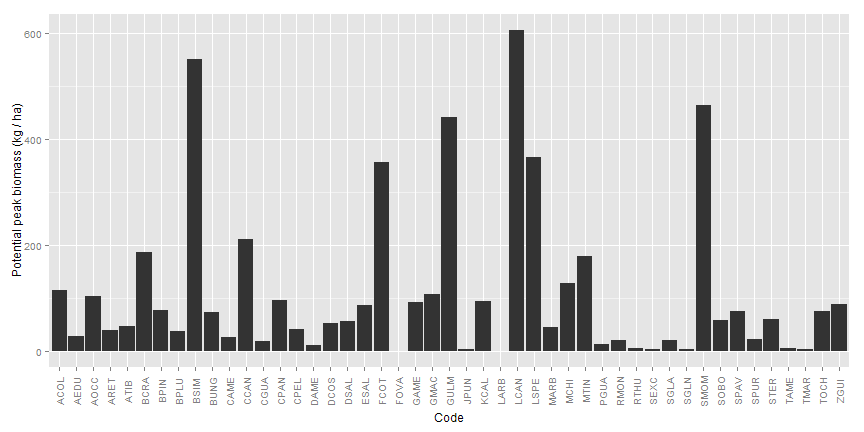

```r
ggplot(biomass, aes(x = code_name,
                    y = biomass_max_kg_ha)) +
  geom_bar(stat = "identity") +
  theme(axis.text.x = element_text(angle = 90, vjust = 0.5)) +
  labs(x = "Code", y = "Potential peak biomass (kg / ha)")
```

## Step 6: Combine phenology with transect data to obtain actual monthly biomass estimates

### Merge fruit index_availability and and biomass data sets

```r
biomass_avail <- merge(fruit_avail,
                       biomass,
                       by.x = "code_name",
                       by.y = "code_name")
biomass_avail <- biomass_avail[with(biomass_avail,
                                    order(code_name, month_of)), ]

# Monthly biomass for each species
biomass_avail$biomass_monthly_kg <-
  biomass_avail$value * biomass_avail$biomass_max_kg_ha
```

### Aggregate to obtain sum for all species in each month

```r
fruit_seas_avail <- ddply(biomass_avail,
                          .(month_of),
                          summarize,
                          combined_monthly_kg =
                            sum(biomass_monthly_kg, na.rm = TRUE))
```

### Plot of monthly biomass estimates

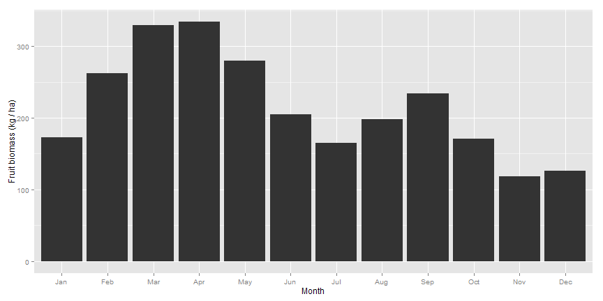

```r
ggplot(fruit_seas_avail,
       aes(x = month_of,
           y = combined_monthly_kg)) +
  geom_bar(stat = "identity") +
  labs(x = "Month", y = "Fruit biomass (kg / ha)")
```

The data are strongly affected by a few large, common species that are either very rarely eaten or have very small, wind-dispersed seeds for which Peters' biomass formula is inappropriate. Therefore, I'm repeating the calculation without these species.

### Without GULM and wind-dispersed seeds: LCAN, LSPE, BUNG, CCAN

```r
biomass_avail <- biomass_avail[biomass_avail$code_name != "GULM" &
                                 biomass_avail$code_name != "LCAN" &
                                 biomass_avail$code_name != "LSPE" &
                                 biomass_avail$code_name != "BUNG" &
                                 biomass_avail$code_name != "CCAN", ]

fruit_seas_avail <- ddply(biomass_avail,
                          .(month_of),
                          summarize,
                          combined_monthly_kg = sum(biomass_monthly_kg,
                                                    na.rm=TRUE))
```

### Plot of monthly biomass estimates

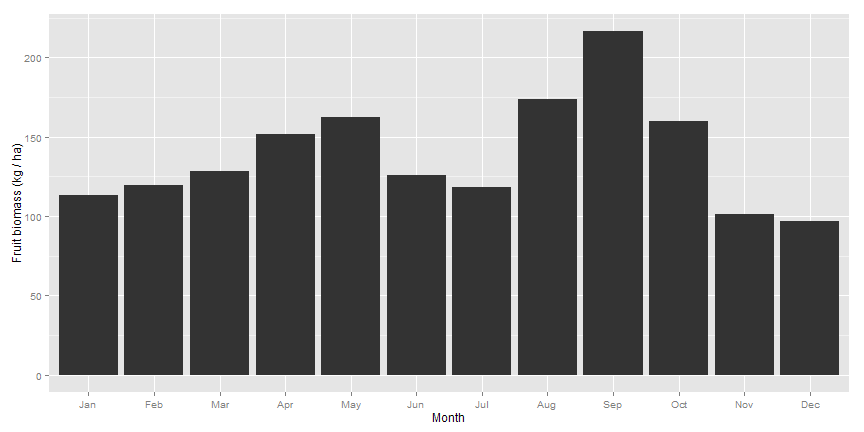

```r
ggplot(fruit_seas_avail,
       aes(x = month_of,
           y = combined_monthly_kg)) +
  geom_bar(stat = "identity") +
  labs(x = "Month", y = "Fruit biomass (kg / ha)")
```

```r
# Write csv for later use
# write.csv(fruit_seas_avail, "biomass_monthly.csv", row.names = FALSE)
```

```r
sum(fruit_seas_avail$combined_monthly_kg)
```

```
## [1] 1667
```

### Interpolation of monthly to daily biomass

```r
# Add one additional january to the end for a complete year
biomass_monthly <- rbind(fruit_seas_avail, fruit_seas_avail[1, ])

# Create actual dates
biomass_monthly$month_num <- match(biomass_monthly$month_of,
                                   month.abb)
biomass_monthly$date_of <- ymd(paste("2011",
                                     biomass_monthly$month_num,
                                     "1",
                                     sep = "-"))
biomass_monthly$day_of_year <- yday(biomass_monthly$date_of)

# Change last day_of_year to 366
biomass_monthly[13, ]$day_of_year <- 366

# Rearrange and create day of year column
biomass_monthly <- biomass_monthly[, c(1,4,5,2)]
biomass_daily <- data.frame(day_of_year = seq(1:365))

# Spline
biomass_daily$spline <- spline(x = biomass_monthly$day_of_year,
                               y = biomass_monthly$combined_monthly_kg,
                               n=365)$y
```

### Plot interpolated biomass over entire annual cycle

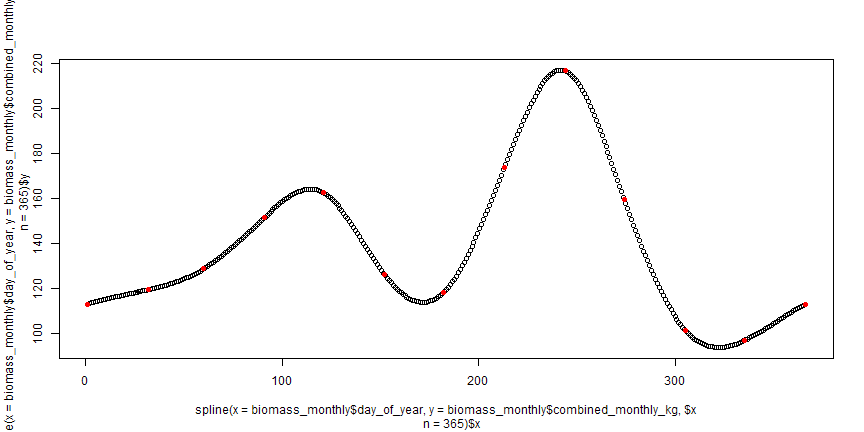

```r
plot(spline(x = biomass_monthly$day_of_year,
            y = biomass_monthly$combined_monthly_kg,
            n=365))
points(x = biomass_monthly$day_of_year,
       y = biomass_monthly$combined_monthly_kg,
       col="red",
       pch=16)
```

```r
start_date <- as.Date("2009-11-16")
end_date <- as.Date("2012-12-15")

biomass_dates <- data.frame(date_of = seq(start_date,
                                          end_date,
                                          by="1 day"))
biomass_dates$day_of_year <- yday(biomass_dates$date_of)

biomass_dates <- merge(biomass_dates, biomass_daily,
                       by.x = "day_of_year",
                       by.y = "day_of_year")[, c(2,1,3)]

biomass_dates <- biomass_dates[with(biomass_dates,
                                    order(date_of)), ]
```

### Plot daily biomass estimate over my study period

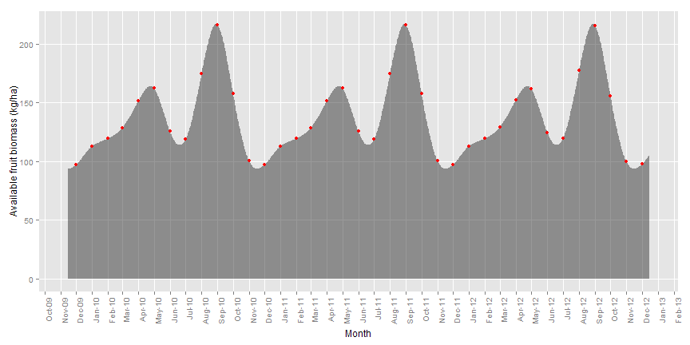

```r
ggplot() +
  geom_area(data = biomass_dates,
            aes(x = as.Date(date_of), y = spline),
            alpha = 0.5) +
  geom_point(data = subset(biomass_dates, day(date_of) == 1),
             aes(x = as.Date(date_of), y = spline),
             color = "red") +
  scale_x_date(breaks="1 months", labels = date_format("%b-%y")) +
  theme(axis.text.x = element_text(angle = 90, hjust = 1),
        panel.grid.minor = element_blank()) +
  labs(x = "Month", y = "Available fruit biomass (kg/ha)")
```